# Integration of omics and clinical data of the hormonal, metabolic, inflammatory, and oxidative response in the different macronutrients of the diet

Statistical Descriptive analysis of the Mircrobiome

Edmond Geraud

27 de noviembre, 2021

# Summary of the univariate descrpitve analysis.

## Overall study.

The data comprises 53 subjects, which are divided into 34 females and 19 males. From the 34 females, 18 are non obese and 16 obese. And 10 non obese males and 9 obese males. The 18 non obese females are divided into 9 PCOS and 9 healthy. The 16 obese females are divided further into 8 PCOS and 8 non PCOS.

A sanity check of the study was performed to observed possibly differences between the groups. No differences were found. Descriptive numerical tables were performed on each data-set except on the microbiome. Numerical descriptive tables only contain the mean and the standard deviation.

For each numerical variable (all except the ones that describes the groups) their distribution were analyzed as a whole, without taking into account the groups (obese, sex and PCOS).

It has to be mentioned that no correlation between variables on the different data types were performed. Only uni variate statistical analysis on each data set was performed.

Permeability markers, and some clinical biomarkers, were analyzed at basal and postprandial times. The first day of the study corresponds to the glucose oral load, the second to the lipids and the third to the proteins.

1. **Clinical data:** Comprises 63 variables. The first variable is the order of the data, the second variable is the sample name, and the next 5 variables belong to sex, group (female, male, PCOS), obese (whether obese or not obese), age and BMI, WC, WHR. And 54 biomarkers. From those 54 biomarkers, there are testosterone, estradiol, its ratio, HOMA-IR, ISI, cholesterol, HDL , LDL, insulin and glucose. Sex steroids, the ratio, HOMA-IR and ISI are only calculated at basal levels. The other variables are calculated also at postprandial level. Furthemore the levels of all these variables the mean basal value for each day of the study is computed.
2. **Permability Biomarkers:** Apart from the categorical variables, we have sCD14, LBP, zonulin and succinate. Each variable the mean basal value is computed,as well as the basal values for each day and the postprandial stage. Succinate is more like a metabolite, however, it was calculated in other units, and we do not know how to include this metablolite. ( No units are specified on this data set)
3. **Metabolome:** The data includes only the sample and the order. And 261 variables. From these variables, only 37 were actually metabolites. The other variables belong to the mean basal values, the basal values for each day, and the postprandial values for each day.

## Set the environment

```r
> list.of.packages <- c("xlsx", "kableExtra", "dplyr", "ggplot2", "egg", "cowplot",
+     "patchwork", "gridExtra", "UsingR", "car", "lattice", "ggpubr", "ggbreak", "GGally",
+     "reshape2", "ggcorrplot", "corrplot", "rela", "ggrepel", "factoextra", "chemometrics",
+     "sparsepca", "vegan", "ca", "ade4")
> new.packages <- list.of.packages[!(list.of.packages %in% installed.packages()[, "Package"])]  ## check for packages not installed
> if (length(new.packages)) install.packages(new.packages)  ## install packages if necessary
> res <- unlist(lapply(list.of.packages, require, character.only = T))  ## load packages needed for the session
> if (any(res == F)) {
+     list.of.packages[which(res == F)]  ## show those package if you have troubles to install.
+ }
>
> list.of.bioc.packages <- c("phyloseq", "pcaMethods")
> new.packages.bioc <- list.of.packages[!(list.of.bioc.packages %in% installed.packages()[,
+     "Package"])]
> if (length(new.packages.bioc)) BiocManager::install(new.packages.bioc)
> res.bioc <- unlist(lapply(list.of.bioc.packages, require, character.only = T))
> if (any(res.bioc == F)) {
+     list.of.packages[which(res.bioc == F)]  ## show those package if you have troubles to install.
+ }
```

### Load the data.

We are going to load the Clinical data and the microbiome, because the microbiome does not have the main factor variables.

```r
> general_data <- read.xlsx(file.path(params$folder.data, params$general.data), sheetIndex = 1)
> general_data$SEX <- factor(general_data$SEX, levels = c(0, 2), labels = c("Female",
+     "Male"))
> general_data$OBESE <- factor(general_data$OBESE, levels = c(0, 1), labels = c("No Obese",
+     "Obese"))
> general_data$GROUP <- factor(general_data$GROUP, levels = c(0, 1, 2), labels = c("Female",
+     "PCOS", "Male"))
>
> bacteria_phylum.abs <- as.data.frame(read.xlsx(file.path(params$folder.data, params$file.data),
+     sheetIndex = 1))
> bacteria_genera.abs <- as.data.frame(t(read.xlsx(file.path(params$folder.data, params$file.data),
+     sheetIndex = 3)))
```

Observations that are in the metagonome dataset.

```r
> variables_in_bacteria <- general_data[general_data$Orden %in% bacteria_phylum.abs$Order,
+     ]
```

The next samples not are in the metagenome dataset

```r
> general_data[!general_data$Orden %in% bacteria_phylum.abs$Order, ][, 1:5]
```

```
   Orden Paciente    SEX  GROUP    OBESE
1      1   MdGLP2 Female Female No Obese
22    22   PdGLP5 Female   PCOS No Obese
25    25  PdGLP10 Female   PCOS No Obese
36    36   VdGLP2   Male   Male No Obese
42    42   VdGLP8   Male   Male No Obese
51    51   VOGLP7   Male   Male    Obese
53    53  VOGLP10   Male   Male    Obese
```

### Some useful functions.

```r
> resumen <- function(x) {
+     c(round(mean(x), 4), round(sd(x), 4))
+ }  # Function that help us to summarize the data in mean and sd values
> lowerFn <- function(data, mapping, method = "lm", ...) {
+     p <- ggplot(data = data, mapping = mapping) + geom_point(colour = "blue") + geom_smooth(method = method,
+         color = "red", ...)
+     p
+ }
>
>
> ## PlotPCA for different methods.
> plotPCA_methods <- function(X.list, factor, title1, title2, size = 1.5, glineas = 0.25,
+     labels.scores, labels.loads) {
+
+     X.scores <- X.list$scores
+     X.loadings <- X.list$loadings
+     colnames(X.scores) <- paste0("PC", 1:dim(X.scores)[2])
+
+     colnames(X.loadings) <- paste0("PC", 1:dim(X.loadings)[2])
+     varianza <- as.data.frame(X.list$var)
+     varianza$PC <- paste0("PC", 1:length(X.list$var))
+     colnames(varianza) <- c("varianza", "PC")
+     # scores
+     X.scores <- as.data.frame(X.scores)
+     Group <- factor[[1]]
+     Group2 <- factor[[2]]
+     colores <- 1:length(levels(Group))
+     # main plot
+     p1 <- ggplot(X.scores, aes(x = PC1, y = PC2)) + theme_classic() + geom_hline(yintercept = 0,
+         color = "gray70") + geom_vline(xintercept = 0, color = "gray70") + geom_point(aes(color = Group,
+         shape = Group2), alpha = 0.55, size = 3) + coord_cartesian(xlim = c(min(X.scores[,
+         1]), max(X.scores[, 1]))) + scale_fill_discrete(name = "Group")
+     # avoiding labels superposition
+
+     grafico <- p1 + geom_text_repel(aes(y = PC2, label = labels.scores), segment.size = 0.25,
+         size = size) + labs(x = c(paste("PC1", round(varianza[1, 1], 2), "%")), y = c(paste("PC2",
+         round(varianza[2, 1], 2), "%"))) + ggtitle(paste("Principal Component Analysis for: ",
+         title1, sep = " ")) + theme(plot.title = element_text(hjust = 0.5)) + scale_color_manual(values = colores)
+
+     X.loadings <- as.data.frame(X.loadings)
+     # main plot
+     p2 <- ggplot(X.loadings, aes(x = PC1, y = PC2)) + theme_classic() + geom_hline(yintercept = 0,
+         color = "gray70") + geom_vline(xintercept = 0, color = "gray70") + geom_point(aes(color = "gray70"),
+         alpha = 0.55, size = 3) + coord_cartesian(xlim = c(min(X.loadings[, 1]),
+         max(X.loadings[, 1])))
+     # avoiding labels superposition
+
+     grafico2 <- p2 + geom_text_repel(aes(label = labels.loads), segment.size = 0.25,
+         size = size) + labs(x = c(paste("PC1", round(varianza[1, 1], 2), "%")), y = c(paste("PC2",
+         round(varianza[2, 1], 2), "%"))) + ggtitle(paste("Principal Component Analysis for: ",
+         title2, sep = " ")) + theme(plot.title = element_text(hjust = 0.5)) + theme(legend.position = "none")
+
+     graficos <- list(grafico, grafico2)
+     return(graficos)
+ }
>
> proces_bacteria <- function(datos, tipo) {
+
+     Order <- bacteria_phylum.abs$Order
+     variables_in_bacteria <- general_data[general_data$Orden %in% Order, ]
+     Sample <- variables_in_bacteria$Paciente
+
+
+     if (tipo == "genera") {
+
+         Order <- Order
+
+         X <- datos[-1, -1]
+         X <- apply(X, 2, as.numeric)
+         colnames(X) <- datos[1, 2:ncol(datos)]
+         rownames(X) <- Sample
+         X.rel <- 100 * X/rowSums(X)
+
+
+     } else if (tipo == "phylum") {
+
+         X <- datos[, -c(1:2)]
+         colnames(X) <- colnames(datos)[3:ncol(datos)]
+         rownames(X) <- Sample
+         X.rel <- 100 * X/rowSums(X)
+     }
+
+     GROUP <- variables_in_bacteria$GROUP
+     SEX <- variables_in_bacteria$SEX
+     OBESE <- variables_in_bacteria$OBESE
+
+     X <- as.data.frame(X)
+     X.rel <- as.data.frame(X.rel)
+
+     X$GROUP <- GROUP
+     X$SEX <- SEX
+     X$OBESE <- OBESE
+
+
+     X.rel$GROUP <- GROUP
+     X.rel$SEX <- SEX
+     X.rel$OBESE <- OBESE
+
+     return(list(abs = X, rel = X.rel))
+
+ }
>
>
> ## Creamos los objetos de phyloseq
>
> create_phyloseq <- function(datos, taxon) {
+
+     GROUP <- variables_in_bacteria$GROUP
+     SEX <- variables_in_bacteria$SEX
+     OBESE <- variables_in_bacteria$OBESE
+     datos <- datos
+
+     X <- datos[, -c(ncol(datos) - 2, ncol(datos) - 1, ncol(datos))]
+
+     Xt <- t(X)
+
+     rownames(Xt) <- paste0("OTU", 1:nrow(Xt))
+     OTU <- otu_table(Xt, taxa_are_rows = T)  # creamos Otu table.
+
+     tax <- as.matrix(colnames(X), ncol = 1)
+     TAX <- tax_table(tax)
+     taxa_names(TAX) <- paste0("OTU", 1:ncol(X))
+     colnames(TAX) <- taxon
+
+
+     ## Creamos sample table
+
+     samples <- as.data.frame(matrix(rep(0, dim(X)[1] * dim(X)[2]), nrow = nrow(X),
+         ncol = 3))
+     samples[, 1] <- GROUP
+     samples[, 2] <- OBESE
+     samples[, 3] <- SEX
+     colnames(samples) <- c("GROUP", "OBESE", "SEX")
+     rownames(samples) <- variables_in_bacteria$Paciente
+     SAM <- sample_data(samples)
+
+     phyloseq_obj <- phyloseq(OTU, TAX, SAM)
+
+     return(phyloseq_obj)
+
+ }
>
> perf <- function(X, X.pred) {
+     # print(dim(X)) print(dim(X.pred))
+     return(abs(norm(X - X.pred, type = "F"))/norm(X, type = "F"))
+
+ }
>
> spca.perf <- function(X, fix_parameter, transpose, scale.) {
+
+     parameter <- seq(1e-10, 1, 0.01)
+     perf.vector <- vector(mode = "numeric", length = length(parameter))
+     if (fix_parameter == "alpha") {
+
+         beta <- parameter
+         alpha <- 1e-04
+         if (transpose == F) {
+
+             for (i in 1:length(parameter)) {
+                 perf.vector[i] <- perf(as.matrix((X)), t(spca((X), alpha = alpha,
+                   beta = beta[i], center = T, scale = scale., verbose = F, k = ncol(X))$loadings))
+
+             }
+             beta <- beta[which.min(perf.vector)]
+             pcx <- spca(X, alpha = alpha, beta = beta, verbose = F, center = T, scale = scale.,
+                 k = ncol(X))
+
+         } else if (transpose == T) {
+
+             for (i in 1:length(parameter)) {
+                 perf.vector[i] <- perf(as.matrix(t(X)), (spca(t(X), alpha = alpha,
+                   beta = beta[i], verbose = F, center = T, scale = scale., k = ncol(X))$scores))
+
+             }
+             beta <- beta[which.min(perf.vector)]
+             pcx <- spca(t(X), alpha = alpha, beta = beta, verbose = F, center = T,
+                 scale = scale., k = ncol(X))
+         }
+
+     } else if (fix_parameter == "beta") {
+
+         alpha <- parameter
+         beta <- 1e-04
+         if (transpose == F) {
+
+             for (i in 1:length(parameter)) {
+                 perf.vector[i] <- perf(as.matrix((X)), t(spca((X), alpha = alpha[i],
+                   beta = beta, center = T, scale = scale., verbose = F, k = ncol(X))$loadings))
+
+             }
+             alpha <- alpha[which.min(perf.vector)]
+             pcx <- spca(X, alpha = alpha, beta = beta, verbose = F, center = T, scale = scale.,
+                 k = ncol(X))
+         } else if (transpose == T) {
+
+             for (i in 1:length(parameter)) {
+                 perf.vector[i] <- perf(as.matrix(t(X)), (spca(t(X), alpha = alpha[i],
+                   center = T, scale = scale., beta = beta, verbose = F, k = ncol(X))$scores))
+
+             }
+
+             alpha <- alpha[which.min(perf.vector)]
+             pcx <- spca(t(X), alpha = alpha, beta = beta, center = T, scale = scale.,
+                 verbose = F, k = ncol(X))
+         }
+
+
+     }
+
+     return(pcx)
+ }
>
> plotCA_methods <- function(ca.obj, factor, title, size = 1.5, glineas = 0.25, labels.bac,
+     labels.samples) {
+
+     X.cord_col_stand <- data.frame(ca.obj$colcoord)
+     X.cord_col_prin <- data.frame(ca.obj$colcoord %*% diag(ca.obj$sv))
+     X.cord_row_stand <- data.frame(ca.obj$rowcoord)
+     X.cord_row_prin <- data.frame(ca.obj$rowcoord %*% diag(ca.obj$sv))
+
+     colnames(X.cord_col_stand) <- paste0("dim", 1:dim(X.cord_col_stand)[2])
+     colnames(X.cord_col_prin) <- paste0("dim", 1:dim(X.cord_col_prin)[2])
+     colnames(X.cord_row_stand) <- paste0("dim", 1:dim(X.cord_row_stand)[2])
+     colnames(X.cord_row_prin) <- paste0("dim", 1:dim(X.cord_row_prin)[2])
+
+     data.plot.col <- as.data.frame(cbind(X.cord_col_stand[, 1], X.cord_col_prin[,
+         2]))
+     colnames(data.plot.col) <- c("dim1", "dim2")
+
+     data.plot.row <- as.data.frame(cbind(X.cord_row_stand[, 1], X.cord_row_prin[,
+         2]))
+     colnames(data.plot.row) <- c("dim1", "dim2")
+     inercia <- data.frame(100 * ca.obj$sv^2/sum(ca.obj$sv^2))
+     colnames(inercia) <- "Inercia"
+     inercia$DIM <- paste("cim", 1:length(ca.obj$sv))
+     Group <- factor[[1]]
+     Group2 <- factor[[2]]
+     colores <- 1:length(levels(Group))
+
+
+     # computamos plot asymétrico con las columnas (bacterias)
+     p1 <- ggplot(data.plot.col, aes(x = dim1, y = dim2)) + theme_classic() + geom_hline(yintercept = 0,
+         color = "gray70") + geom_vline(xintercept = 0, color = "gray70") + coord_cartesian(xlim = c(min(data.plot.col[,
+         1]), max(data.plot.col[, 1])))
+
+
+     # avoiding labels superposition
+
+     grafico_columnas <- p1 + geom_text_repel(aes(y = dim2, label = labels.bac), segment.size = 0.1,
+         size = size) + geom_point(aes(y = dim2)) + labs(x = c(paste("dim1", round(inercia[1,
+         1], 2), "%")), y = c(paste("dim2", round(inercia[2, 1], 2), "%"))) + ggtitle(paste("Canonical Correlation Analysis: Columns asymetric plot for ",
+         title, sep = " ")) + theme(plot.title = element_text(hjust = 0.5))
+
+
+
+     # main plot
+     p2 <- ggplot(data.plot.row, aes(x = dim1, y = dim2)) + theme_classic() + geom_hline(yintercept = 0,
+         color = "gray70") + geom_vline(xintercept = 0, color = "gray70") + geom_point(aes(color = Group,
+         shape = Group2), alpha = 0.55, size = 3) + scale_fill_discrete(name = "Group") +
+         coord_cartesian(xlim = c(min(data.plot.row[, 1]), max(data.plot.row[, 1])))
+     # avoiding labels superposition
+
+     grafico_filas <- p2 + geom_text_repel(aes(label = labels.samples), segment.size = 0.25,
+         size = size) + labs(x = c(paste("dim1", round(inercia[1, 1], 2), "%")), y = c(paste("dim2",
+         round(inercia[2, 1], 2), "%"))) + ggtitle(paste("Canonical Correlation Analysis: Rows asymetric plot for: ",
+         title, sep = " ")) + theme(plot.title = element_text(hjust = 0.5)) + theme(legend.position = "right")
+
+     onjeto_cca <- list(plot_cols = grafico_columnas, plot_rows = grafico_filas, prin_rows = X.cord_row_prin,
+         stand_rows = X.cord_row_stand, prin_cols = X.cord_col_prin, stand_cols = X.cord_col_stand)
+     return(onjeto_cca)
+ }
>
>
>
>
> plotMDS <- function(mds.obj, factor, title, labels, method, size = 1.5, glineas = 0.25) {
+
+     Group <- factor[[1]]
+     Group2 <- factor[[2]]
+     colores <- 1:length(levels(Group))
+     if (method == "meta") {
+
+         X.points <- data.frame(mds.obj$points)
+         X.scores <- data.frame(mds.obj$species)
+
+         # main plot
+         p1 <- ggplot(X.points, aes(x = MDS1, y = MDS2)) + theme_classic() + geom_hline(yintercept = 0,
+             color = "gray70") + geom_vline(xintercept = 0, color = "gray70") + geom_point(aes(color = Group,
+             shape = Group2), alpha = 0.55, size = 3) + coord_cartesian(xlim = c(min(c(X.points[,
+             1], X.scores[, 1])), max(c(X.points[, 1], X.scores[, 1])))) + scale_fill_discrete(name = "Group")
+         # avoiding labels superposition
+
+         grafico <- p1 + geom_text_repel(aes(y = MDS2, label = labels), segment.size = 0.25,
+             size = size) + labs(y = c(paste("stress", round(100 * mds.obj$stress,
+             2), "%"))) + ggtitle(paste("Non-metric MDS (meta) for ", title, sep = " ")) +
+             theme(plot.title = element_text(hjust = 0.5)) + scale_color_manual(values = colores)
+
+         grafico2 <- ggplot(data = X.scores, aes(MDS1, MDS2)) + geom_text_repel(data = X.scores,
+             aes(y = MDS2, label = rownames(X.scores)), segment.size = 0.25, size = 2) +
+             labs(y = c(paste("Total stress", 100 * round(mds.obj$stress, 2), "%"))) +
+             ggtitle(paste("Non-metric MDS (meta) for ", title, sep = " ")) + coord_cartesian(xlim = c(min(X.points[,
```

```r
+             1]), max(X.points[, 1]))) + theme(plot.title = element_text(hjust = 0.5))
+
+
+         resultado <- list(grafico1 = grafico, grafico2 = grafico2, dim1_samples = X.points[,
+             1], dim2_samples = X.points[, 2], dim1_species = X.scores[, 1], dim2_species = X.scores[,
+             2])
+
+
+
+     } else if (method == "iso") {
+         X.points <- data.frame(mds.obj$points)
+
+         colnames(X.points) <- paste0("MDS", 1:ncol(X.points))
+         colores <- 1:length(levels(Group))
+         # main plot
+         p1 <- ggplot(X.points, aes(x = MDS1, y = MDS2)) + theme_classic() + geom_hline(yintercept = 0,
+             color = "gray70") + geom_vline(xintercept = 0, color = "gray70") + geom_point(aes(color = Group,
+             shape = Group2), alpha = 0.55, size = 3) + coord_cartesian(xlim = c(min(X.points[,
+             1]), max(X.points[, 1]))) + scale_fill_discrete(name = "Group")
+         # avoiding labels superposition
+
+         grafico <- p1 + geom_text_repel(aes(y = MDS2, label = labels), segment.size = 0.25,
+             size = size) + labs(y = c(paste("Total stress", round(mds.obj$stress,
+             2), "%"))) + ggtitle(paste("Non-metric MDS (iso) for ", title, sep = " ")) +
+             theme(plot.title = element_text(hjust = 0.5)) + scale_color_manual(values = colores)
+
+
+         resultado <- list(grafico1 = grafico, dim1_samples = X.points[, 1], dim2_samples = X.points[,
+             2])
+     }
+
+
+     return(resultado)
+ }
>
>
> plotPcoA <- function(mds.obj, factor, title, labels, size = 1.5, glineas = 0.25) {
+
+     Group <- factor[[1]]
+     Group2 <- factor[[2]]
+     colores <- 1:length(levels(Group))
+     varianza <- 100 * round(mds.obj$eig/sum(mds.obj$eig), 2)
+     X.points <- data.frame(mds.obj$points)
+
+     colnames(X.points) <- paste0("PC", 1:ncol(X.points))
+     colores <- 1:length(levels(Group))
+     # main plot
+     p1 <- ggplot(X.points, aes(x = PC1, y = PC2)) + theme_classic() + geom_hline(yintercept = 0,
+         color = "gray70") + geom_vline(xintercept = 0, color = "gray70") + geom_point(aes(color = Group,
+         shape = Group2), alpha = 0.55, size = 3) + coord_cartesian(xlim = c(min(X.points[,
+         1]), max(X.points[, 1]))) + scale_fill_discrete(name = "Group")
+     # avoiding labels superposition
+
+     grafico <- p1 + geom_text_repel(aes(y = PC2, label = labels), segment.size = 0.25,
+         size = size) + labs(x = c(paste("PC1", round(varianza[1], 2), "%")), y = c(paste("PC2",
+         round(varianza[2], 2), "%"))) + ggtitle(paste("PCoA for ", title, sep = " ")) +
+         theme(plot.title = element_text(hjust = 0.5)) + scale_color_manual(values = colores)
+
+
+     resultado <- list(grafico1 = grafico, dim1_samples = X.points[, 1], dim2_samples = X.points[,
+         2])
+
+
+
+     return(resultado)
+ }
```

Before start the analysis, let’s create `phyloseq` objects.

```r
> phylum.list <- proces_bacteria(bacteria_phylum.abs, tipo = "phylum")
> genera.list <- proces_bacteria(bacteria_genera.abs, tipo = "genera")
>
> phylum.abs <- phylum.list$abs
> phylum.rel <- phylum.list$rel
> genera.abs <- genera.list$abs
> genera.rel <- genera.list$rel
```

```r
> phyloseq_phyla_abs <- create_phyloseq(phylum.abs, "phylum")
> phyloseq_phyla_rel <- create_phyloseq(phylum.rel, "phylum")
>
> phyloseq_genera_abs <- create_phyloseq(genera.abs, "genus")
> phyloseq_genera_rel <- create_phyloseq(genera.rel, "genus")
```

## Sanity check.

```r
> (sexo <- table(phyloseq_genera_abs@sam_data$SEX))
```

```
Female   Male
    31     15
```

```r
> (sexo.obesos <- table(phyloseq_genera_abs@sam_data$OBESE))
```

```
No Obese    Obese
      23       23
```

```r
> (subgrupos <- table(phyloseq_genera_abs@sam_data$GROUP, phyloseq_genera_abs@sam_data$OBESE))
```

```
         No Obese Obese
  Female        8     8
  PCOS          7     8
  Male          8     7
```

```r
> chisq.test(sexo.obesos)
```

```
    Chi-squared test for given probabilities

data:  sexo.obesos
X-squared = 0, df = 1, p-value = 1
```

```r
> chisq.test(subgrupos)
```

```
    Pearson's Chi-squared test

data:  subgrupos
X-squared = 0.13333, df = 2, p-value = 0.9355
```

## Statistical descriptive analysis: Phylum.

### Descriptive numerical table.

We are going to perform the descriptive analysis on the relative abundance firstly by a numerical descriptive table.

```r
> phylum.variables <- phylum.rel  ## remove samples names and order from the summary
>
>
> phylum.sum <- phylum.variables %>%
+     group_by(GROUP, OBESE) %>%
+     summarise(across(where(is.numeric), resumen), n = n()) %>%
+     mutate_if(is.numeric, format, 4)  # Group the data by variable GROUP and OBESE
>
> d.f <- as.data.frame(t(phylum.sum))[c(nrow(t(phylum.sum)), 1:(nrow(t(phylum.sum)) -
+     1)), ]  # transpose the data for visualization purposes and get rid off the N value for same purposes
>
> # name of each variable.
> nombre_phylum_variable <- colnames(phylum.variables)[-c(ncol(phylum.variables) -
+     2, ncol(phylum.variables) - 1, ncol(phylum.variables))]
>
> colnames(d.f) <- rep(c("Mean", "SD"), 6)
> d.f_final <- d.f[-c(1:3), ]
> ## ATTENION! Because assining left hand expression is complicated, just for one
> ## table, be careful if we put another data-set For showing the number of
> ## subjects by group
> as.data.frame(d.f_final)
```

```
                               Mean      SD    Mean      SD    Mean      SD
Firmicutes                  73.4686 19.4854 76.3222 10.5519 70.4499 13.6843
Bacteroidetes               13.6980 14.1474 15.3537 11.2163 21.7426 11.5428
Proteobacteria               1.4068  1.6908  0.9125  0.6621  1.3164  1.1970
Actinobacteria               6.9028  4.6793  5.5297  3.3605  2.2597  1.2734
Verrucomicrobia              3.2983  8.2859  1.4552  2.2555  2.6165  4.3640
Candidatus.Saccharibacteria  0.0229  0.0167  0.0913  0.1010  0.0156  0.0122
Chlamydiae                        0       0       0       0       0       0
Chloroflexi                       0       0       0       0       0       0
Cyanobacteria.Chloroplast    0.0057  0.0074  0.0047  0.0079  0.0313  0.0707
Elusimicrobia                 3e-04   8e-04       0       0       0       0
Euryarchaeota                0.1892  0.3911  0.1687  0.3794  0.4592  0.6478
Fusobacteria                 0.0058  0.0101  0.0065  0.0111   7e-04   8e-04
Gemmatimonadetes                  0       0       0       0       0       0
Lentisphaerae                 3e-04   8e-04       0       0   3e-04   8e-04
Nitrospirae                       0       0       0       0       0       0
Parcubacteria                     0       0       0       0       0       0
Spirochaetes                      0       0       0       0       0       0
SR1                               0       0       0       0   1e-04   3e-04
Synergistetes                0.0188  0.0463       0       0  0.0514  0.1045
Tenericutes                       0       0       0       0       0       0
ud.Archaea                   0.0316  0.0351  0.0048  0.0065  0.0573  0.0281
ud.Bacteria                  0.9510  0.9334  0.1505  0.0875  0.9990  0.6533
                               Mean      SD    Mean      SD    Mean      SD
Firmicutes                  75.1677 12.8644 70.7162 12.7930 75.6603 12.9987
Bacteroidetes               12.8227 10.7925 21.3867  9.2557 13.6272  7.5690
Proteobacteria               3.1519  6.8972  1.3445  1.5001  4.2092  7.0686
Actinobacteria               6.2568  6.8764  5.7679  8.9340  5.7817  3.6947
Verrucomicrobia              1.8594  3.7896  0.5520  0.8951  0.0603  0.0827
Candidatus.Saccharibacteria  0.0759  0.1135  0.0303  0.0227  0.0424  0.0295
Chlamydiae                        0       0       0       0       0       0
Chloroflexi                       0       0   1e-04   4e-04       0       0
Cyanobacteria.Chloroplast    0.0042  0.0048  0.0257  0.0508  0.0045  0.0063
Elusimicrobia                     0       0       0       0       0       0
Euryarchaeota                0.0368  0.0769  0.0028  0.0075  0.4065  0.6099
Fusobacteria                 0.0012  0.0016  0.0039  0.0069  0.0022  0.0028
Gemmatimonadetes                  0       0       0       0       0       0
Lentisphaerae                0.0005  0.0015       0       0       0       0
Nitrospirae                       0       0       0       0   1e-04   2e-04
Parcubacteria                     0       0       0       0   3e-04   8e-04
Spirochaetes                      0       0       0       0       0       0
SR1                               0       0       0       0       0       0
Synergistetes                0.0199  0.0538  0.0030  0.0085  0.0004  0.0012
Tenericutes                       0       0   3e-04   8e-04   3e-04   8e-04
ud.Archaea                   0.0690  0.0519  0.0015  0.0025   8e-04   1e-03
ud.Bacteria                  0.5341  0.4632  0.1651  0.1029  0.2039  0.2078
```

```r
> kbl(d.f_final, digits = c(rep(4, 12), 0)) %>%
+     kable_classic_2() %>%
+     add_header_above(c(` ` = 1, `8` = 2, `8` = 2, `7` = 2, `8` = 2, `8` = 2, `7` = 2)) %>%
+     add_header_above(c(` ` = 1, `No Obese` = 2, Obese = 2, `No Obese` = 2, Obese = 2,
+         `No Obese` = 2, Obese = 2)) %>%
+     add_header_above(c(` ` = 1, `Control Females` = 4, PCOS = 4, `Control Males` = 4))
```

|  | Control Females No Obese 8 Mean | Control Females No Obese 8 SD | Control Females Obese 8 Mean | Control Females Obese 8 SD | PCOS No Obese 7 Mean | PCOS No Obese 7 SD | PCOS Obese 8 Mean | PCOS Obese 8 SD | Control Males No Obese 8 Mean | Control Males No Obese 8 SD | Control Males Obese 7 Mean | Control Males Obese 7 SD |
| --- | --- | --- | --- | --- | --- | --- | --- | --- | --- | --- | --- | --- |
| Firmicutes | 73.4686 | 19.4854 | 76.3222 | 10.5519 | 70.4499 | 13.6843 | 75.1677 | 12.8644 | 70.7162 | 12.7930 | 75.6603 | 12.9987 |
| Bacteroidetes | 13.6980 | 14.1474 | 15.3537 | 11.2163 | 21.7426 | 11.5428 | 12.8227 | 10.7925 | 21.3867 | 9.2557 | 13.6272 | 7.5690 |
| Proteobacteria | 1.4068 | 1.6908 | 0.9125 | 0.6621 | 1.3164 | 1.1970 | 3.1519 | 6.8972 | 1.3445 | 1.5001 | 4.2092 | 7.0686 |
| Actinobacteria | 6.9028 | 4.6793 | 5.5297 | 3.3605 | 2.2597 | 1.2734 | 6.2568 | 6.8764 | 5.7679 | 8.9340 | 5.7817 | 3.6947 |
| Verrucomicrobia | 3.2983 | 8.2859 | 1.4552 | 2.2555 | 2.6165 | 4.3640 | 1.8594 | 3.7896 | 0.5520 | 0.8951 | 0.0603 | 0.0827 |
| Candidatus.Saccharibacteria | 0.0229 | 0.0167 | 0.0913 | 0.1010 | 0.0156 | 0.0122 | 0.0759 | 0.1135 | 0.0303 | 0.0227 | 0.0424 | 0.0295 |
| Chlamydiae | 0 | 0 | 0 | 0 | 0 | 0 | 0 | 0 | 0 | 0 | 0 | 0 |
| Chloroflexi | 0 | 0 | 0 | 0 | 0 | 0 | 0 | 0 | 1e-04 | 4e-04 | 0 | 0 |
| Cyanobacteria.Chloroplast | 0.0057 | 0.0074 | 0.0047 | 0.0079 | 0.0313 | 0.0707 | 0.0042 | 0.0048 | 0.0257 | 0.0508 | 0.0045 | 0.0063 |
| Elusimicrobia | 3e-04 | 8e-04 | 0 | 0 | 0 | 0 | 0 | 0 | 0 | 0 | 0 | 0 |
| Euryarchaeota | 0.1892 | 0.3911 | 0.1687 | 0.3794 | 0.4592 | 0.6478 | 0.0368 | 0.0769 | 0.0028 | 0.0075 | 0.4065 | 0.6099 |
| Fusobacteria | 0.0058 | 0.0101 | 0.0065 | 0.0111 | 7e-04 | 8e-04 | 0.0012 | 0.0016 | 0.0039 | 0.0069 | 0.0022 | 0.0028 |
| Gemmatimonadetes | 0 | 0 | 0 | 0 | 0 | 0 | 0 | 0 | 0 | 0 | 0 | 0 |
| Lentisphaerae | 3e-04 | 8e-04 | 0 | 0 | 3e-04 | 8e-04 | 0.0005 | 0.0015 | 0 | 0 | 0 | 0 |
| Nitrospirae | 0 | 0 | 0 | 0 | 0 | 0 | 0 | 0 | 0 | 0 | 1e-04 | 2e-04 |
| Parcubacteria | 0 | 0 | 0 | 0 | 0 | 0 | 0 | 0 | 0 | 0 | 3e-04 | 8e-04 |
| Spirochaetes | 0 | 0 | 0 | 0 | 0 | 0 | 0 | 0 | 0 | 0 | 0 | 0 |
| SR1 | 0 | 0 | 0 | 0 | 1e-04 | 3e-04 | 0 | 0 | 0 | 0 | 0 | 0 |
| Synergistetes | 0.0188 | 0.0463 | 0 | 0 | 0.0514 | 0.1045 | 0.0199 | 0.0538 | 0.0030 | 0.0085 | 0.0004 | 0.0012 |
| Tenericutes | 0 | 0 | 0 | 0 | 0 | 0 | 0 | 0 | 3e-04 | 8e-04 | 3e-04 | 8e-04 |
| ud.Archaea | 0.0316 | 0.0351 | 0.0048 | 0.0065 | 0.0573 | 0.0281 | 0.0690 | 0.0519 | 0.0015 | 0.0025 | 8e-04 | 1e-03 |
| ud.Bacteria | 0.9510 | 0.9334 | 0.1505 | 0.0875 | 0.9990 | 0.6533 | 0.5341 | 0.4632 | 0.1651 | 0.1029 | 0.2039 | 0.2078 |

### Diversity.

Now we are going to compute the beta and alpha diversity.

#### Alpha diversity.

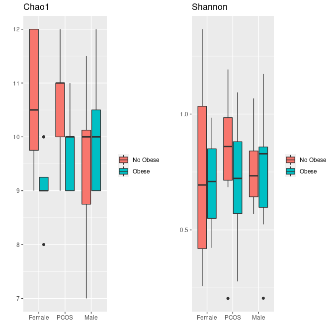

```r
> phylum.abs.curated <- prune_species(speciesSums(phyloseq_phyla_abs) > 0, phyloseq_phyla_abs)
> alpha <- estimate_richness(phylum.abs.curated, measures = c("Shannon", "Chao1"))
> alpha$GROUP <- variables_in_bacteria$GROUP
> alpha$OBESE <- variables_in_bacteria$OBESE
> p1 <- ggplot(alpha, aes(x = GROUP, y = Chao1, interaction(alpha$GROUP), fill = alpha$OBESE)) +
+     geom_boxplot() + ylab("") + xlab("") + ggtitle("Chao1") + theme(legend.title = element_blank())
> p2 <- ggplot(alpha, aes(x = GROUP, y = Shannon, interaction(alpha$GROUP), fill = alpha$OBESE)) +
+     geom_boxplot() + ylab("") + xlab("") + ggtitle("Shannon") + theme(legend.title = element_blank())
> grid.arrange(p1, p2, ncol = 2)
```

#### Beta diversity.

##### Jaccard Index.

```r
> X.phylum <- phylum.abs[, -c(ncol(phylum.abs) - 2, ncol(phylum.abs) - 1, ncol(phylum.abs))]
> dim(X.phylum)
```

```
[1] 46 22
```

```r
> X.phylum <- X.phylum[, colSums(X.phylum) > 0]
> dim(X.phylum)
```

```
[1] 46 19
```

```r
> jaccard_phylum_D <- vegdist(X.phylum, method = "jaccard")
> is.euclid(jaccard_phylum_D)
```

```
[1] FALSE
```

Cómo la distancia no es euclídea procedemos con un escalado multidimensional no métrico.

```r
> nmds_ids_phylum <- isoMDS(jaccard_phylum_D, trace = F)
> nmds_ids_phylum$stress
```

```
[1] 9.823882
```

```r
> nmds_meta_phylum <- vegan::metaMDS(X.phylum, distance = "jaccard", engine = "monoMDS",
+     trace = F)
> nmds_meta_phylum$stress * 100
```

```
[1] 22.26715
```

Utilizamos el engine `isoMDS` procedemos a graficar.

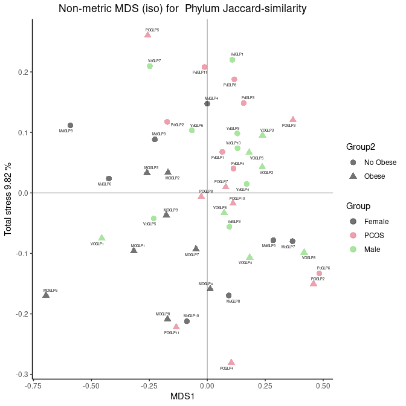

```r
> grupos <- list(variables_in_bacteria$GROUP, variables_in_bacteria$OBESE)
> res_iso_phylum <- plotMDS(nmds_ids_phylum, grupos, title = "Phylum Jaccard-similarity",
+     labels = rownames(X.phylum), method = "iso")
> res_iso_phylum$grafico1
```

##### Soersen Index

```r
> soersen_phylum_D <- vegdist(t(X.phylum), method = "bray", binary = T)
> is.euclid(soersen_phylum_D)
```

```
[1] FALSE
```

The distance is not euclidean, thus we proceed with non-metric MDS

```r
> # nmds_ids_phylum <- isoMDS(soersen_phylum_D,trace=F) nmds_ids_phylum$stress #
> # no se puede calcular
>
> nmds_meta_phylum_soersen <- vegan::metaMDS(X.phylum, engine = "monoMDS", trace = F,
+     binary = T, autotransform = T)
> nmds_meta_phylum_soersen$stress * 100
```

```
[1] 15.98256
```

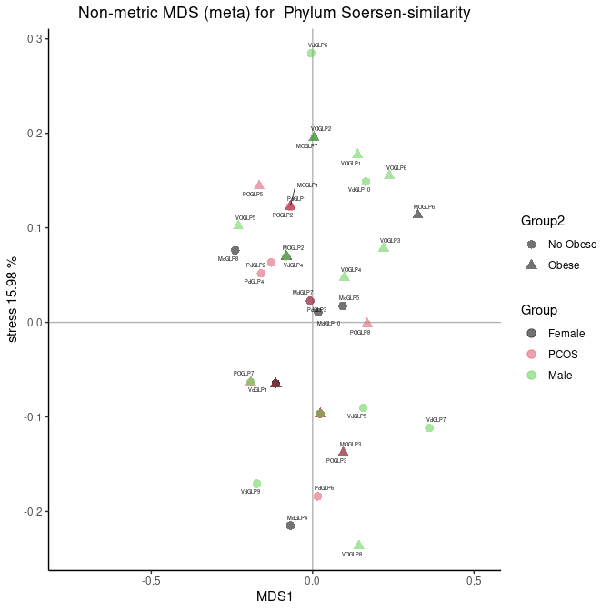

```r
> #
> res_meta_phylum <- plotMDS(nmds_meta_phylum_soersen, grupos, title = "Phylum Soersen-similarity",
+     labels = rownames(X.phylum), method = "meta")
>
> res_meta_phylum$grafico1
```

### Statisitcal Multivariate Descriptive analysis.

Due to the fact that we are dealing with with presence or absence of data, the best choice is to perform a Canonical Correspondence Analysis.

```r
> ca.phylum <- ca(X.phylum)
```

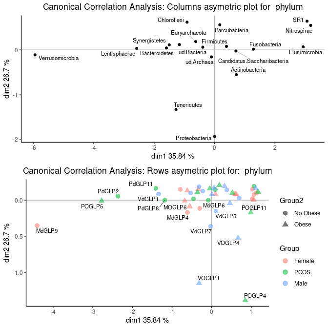

```r
> plot_phylum <- plotCA_methods(ca.phylum, grupos, "phylum", labels.bac = colnames(X.phylum),
+     labels.samples = rownames(X.phylum), size = 3)
>
> grid.arrange(plot_phylum$plot_cols, plot_phylum$plot_rows)
```

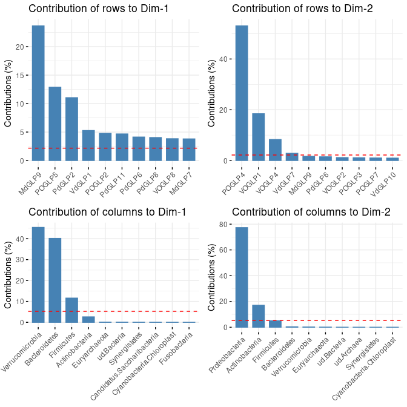

```r
> p1 <- fviz_contrib(ca.phylum, choice = "row", axes = 1, top = 10)
> # Contributions of rows to dimension 2
> p2 <- fviz_contrib(ca.phylum, choice = "row", axes = 2, top = 10)
>
> # Contributions of cols to dimension 1
> p3 <- fviz_contrib(ca.phylum, choice = "col", axes = 1, top = 10)
> # Contributions of cols to dimension 2
> p4 <- fviz_contrib(ca.phylum, choice = "col", axes = 2, top = 10)
> grid.arrange(p1, p2, p3, p4, ncol = 2)
```

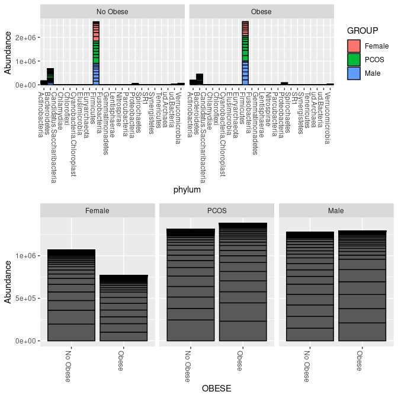

```r
> p1 <- plot_bar(phyloseq_phyla_abs, x = "phylum", fill = "GROUP", facet_grid = ~OBESE)
> p2 <- plot_bar(phyloseq_phyla_abs, x = "OBESE", facet_grid = ~GROUP)
> grid.arrange(p1, p2)
```

### Statistical Univariate Analysis

```r
> variables <- colnames(phylum.rel)
> hist.list.meta <- list()  ## initizalize a list of the histogram
> ## plot all histograms via loop
> for (i in 1:length(variables)) {
+     if (variables[i] == "Order" || variables[i] == "Sample") {
+         next
+     } else if (class(phylum.rel[, i]) == "factor") {
+         next
+     }
+     variable <- variables[i]  ## name of the variable to plot
+     titulo <- colnames(phylum.rel)[i]  # title of the varialbe
+
+     breaks <- pretty(range(phylum.rel[, variable]), n = nclass.Sturges(phylum.rel[,
+         variable]), min.n = 1)  # make pretty histogram by appropiate bins
+     bwidth <- breaks[2] - breaks[1]  ## bin width
+
+     ## plot
+     hist.list.meta[[i]] <- ggplot(phylum.rel, aes_string(x = variable)) + geom_histogram(aes(y = ..density..),
+         binwidth = bwidth, colour = "black") + geom_density(alpha = 0.2, fill = "lightblue") +
+         xlab(titulo) + ylab("")
+
+
+ }
>
>
> bp.interaction <- list()  ## intialize boxplot list interaction
> for (i in 1:length(variables)) {
+     if (class(variables[i]) == "factor") {
+         next
+     }
+     titulo <- colnames(phylum.rel)[i]
+     variable <- variables[i]
+     bp.interaction[[i]] <- ggplot(phylum.rel, aes_string(x = phylum.rel$GROUP, y = variable,
+         interaction(phylum.rel$GROUP), fill = phylum.rel$OBESE)) + geom_boxplot() +
+         ylab(titulo) + xlab("") + theme(legend.title = element_blank())
+
+ }
```

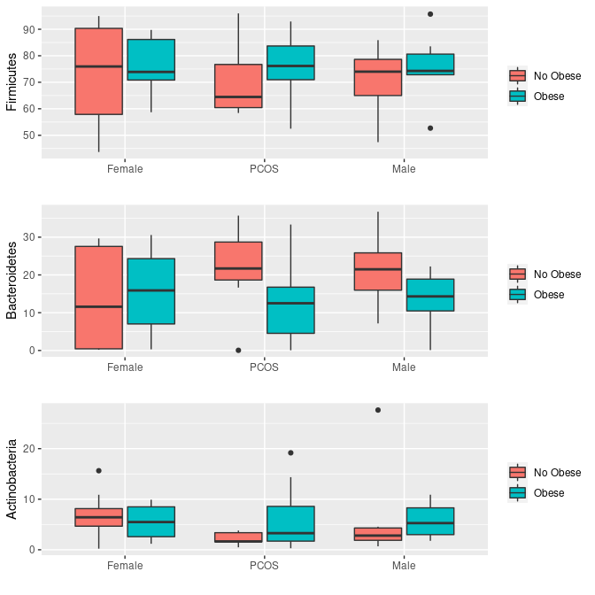

```r
> ### plots
> grid.arrange(bp.interaction[[1]], bp.interaction[[2]], bp.interaction[[4]])
```

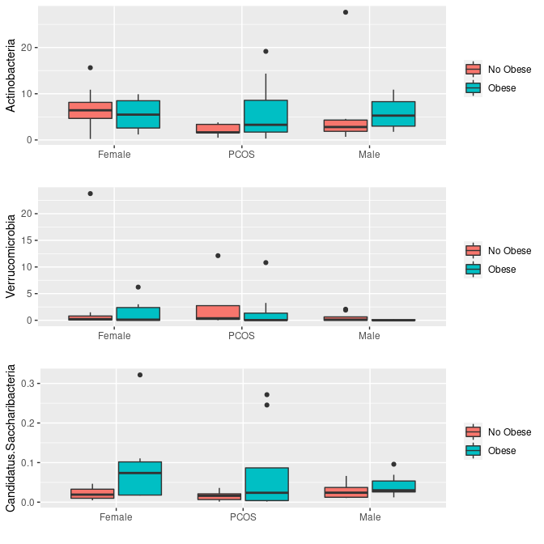

```r
> grid.arrange(bp.interaction[[4]], bp.interaction[[5]], bp.interaction[[6]])
```

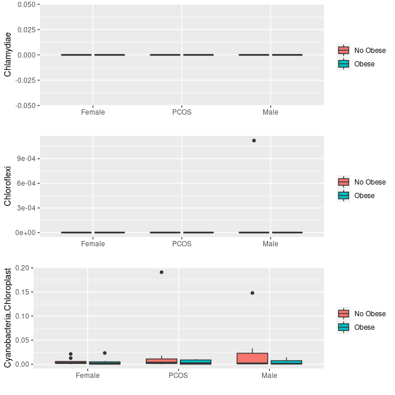

```r
> grid.arrange(bp.interaction[[7]], bp.interaction[[8]], bp.interaction[[9]])
```

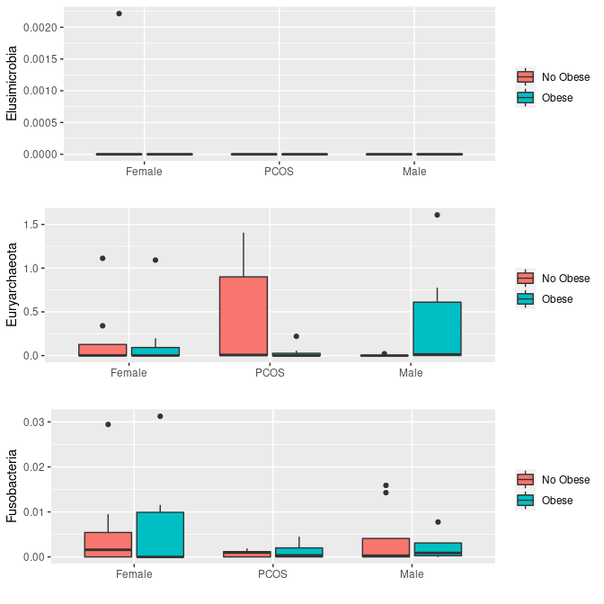

```r
> grid.arrange(bp.interaction[[10]], bp.interaction[[11]], bp.interaction[[12]])
```

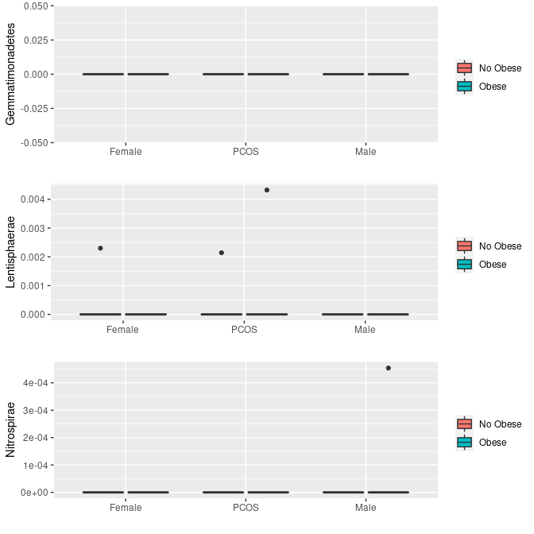

```r
> grid.arrange(bp.interaction[[13]], bp.interaction[[14]], bp.interaction[[15]])
```

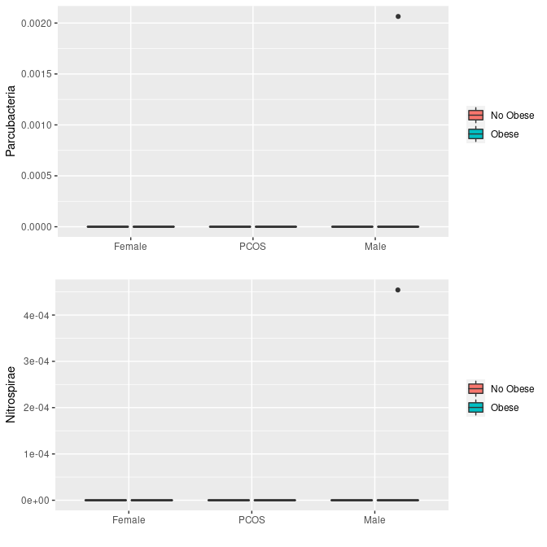

```r
> grid.arrange(bp.interaction[[16]], bp.interaction[[15]])
```

## Statistical descriptive analysis: Genus.

We are going to perform the descriptive analysis on the relative abundance.

```r
> genus.variables <- genera.rel  ## remove samples names and order from the summary
>
>
> phylum.sum <- genus.variables %>%
+     group_by(GROUP, OBESE) %>%
+     summarise(across(where(is.numeric), resumen), n = n()) %>%
+     mutate_if(is.numeric, format, 4)  # Group the data by variable GROUP and OBESE
>
> d.f <- as.data.frame(t(phylum.sum))[c(nrow(t(phylum.sum)), 1:(nrow(t(phylum.sum)) -
+     1)), ]  # transpose the data for visualization purposes and get rid off the N value for same purposes
>
> # name of each variable.
> nombre_phylum_variable <- colnames(genus.variables)[-c(ncol(genus.variables) - 2,
+     ncol(genus.variables) - 1, ncol(genus.variables))]
>
> colnames(d.f) <- rep(c("Mean", "SD"), 6)
> d.f_final <- d.f[-c(1:3), ]
> ## ATTENION! Because assining left hand expression is complicated, just for one
> ## table, be careful if we put another data-set For showing the number of
> ## subjects by group
> as.data.frame(d.f_final)
```

```
                                          Mean      SD    Mean      SD    Mean
Abiotrophia                              6e-04   9e-04  0.0013  0.0022   2e-04
Acetanaerobacterium                     0.0117  0.0156  0.0045  0.0061  0.0012
Acidaminococcus                         0.0084  0.0156  0.7027  1.9139  0.0673
Acidovorax                              0.0009  0.0026       0       0       0
Acinetobacter                           0.0004  0.0013       0       0       0
Actinomyces                             0.0297  0.0154  0.0753  0.0925  0.0201
Adlercreutzia                            2e-04   5e-04   2e-04   5e-04   1e-04
Aerococcus                                   0       0   2e-04   5e-04       0
Aestuariispira                           2e-04   6e-04       0       0       0
Aggregatibacter                              0       0       0       0       0
Akkermansia                             2.7154  6.8303  1.1232  1.6917  2.4571
Alistipes                               0.7839  1.2002  0.9815  1.1379  2.7203
Allisonella                             0.0031  0.0088       0       0  0.0072
Alloprevotella                          0.3127  0.8810       0       0  0.5221
Anaerobacter                             1e-04   3e-04       0       0       0
Anaerococcus                            0.0013  0.0016  0.0005  0.0014  0.0008
Anaerofilum                             0.0034  0.0045  0.0023  0.0024  0.0069
Anaerofustis                            0.0014  0.0040  0.0011  0.0013       0
Anaeroglobus                                 0       0       0       0       0
Anaerorhabdus                                0       0       0       0       0
Anaerospora                                  0       0       0       0   2e-04
Anaerosporobacter                            0       0       0       0   2e-04
Anaerostipes                            0.7464  0.7847  0.2680  0.3101  0.6600
Anaerotruncus                           0.0227  0.0197  0.0125  0.0168  0.1542
Anaerovorax                              1e-04   4e-04   4e-04   7e-04       0
Asaccharobacter                         0.0013  0.0031   2e-04   4e-04   2e-04
Atopobium                               0.0020  0.0024  0.0140  0.0124  0.0042
Bacillus                                0.0007  0.0019       0       0   1e-04
Bacteroides                             9.6784 10.7641 11.5552 10.9127  8.7778
Barnesiella                             0.3496  0.6510  0.7901  0.8864  0.6999
Bdellovibrio                                 0       0  0.0006  0.0016       0
Bifidobacterium                         3.7876  3.1955  2.5467  1.7158  0.9263
Bilophila                               0.0449  0.0615  0.0270  0.0258  0.0932
Blautia                                 2.5605  0.9455  1.6278  0.7773  1.4855
Brevibacillus                            3e-04   6e-04       0       0   3e-04
Bulleidia                                    0       0       0       0   1e-04
Burkholderia                            0.0011  0.0023       0       0   1e-04
Buttiauxella                                 0       0       0       0       0
Butyricicoccus                          0.1102  0.0765  0.1999  0.1690  0.2684
```

[output cut: 794 more lines]

```
ud-Sphingomonadaceae                         0      0
ud-Staphylococcaceae                         0      0
ud-Streptococcaceae                      1e-04  2e-04
ud-Succinivibrionaceae                       0      0
ud-Sutterellaceae                            0      0
ud-Synergistaceae                            0      0
ud-Syntrophomonadaceae                       0      0
ud-Veillonellaceae                      0.0033 0.0061
Vampirovibrio                                0      0
Varibaculum                                  0      0
Veillonella                             0.0514 0.1073
Victivallis                                  0      0
Weeksella                                    0      0
Weissella                               0.0132 0.0338
Yersinia                                0.0083 0.0220
```

```r
> kbl(d.f_final, digits = c(rep(4, 12), 0)) %>%
+     kable_classic_2() %>%
+     add_header_above(c(` ` = 1, `8` = 2, `8` = 2, `7` = 2, `8` = 2, `8` = 2, `7` = 2)) %>%
+     add_header_above(c(` ` = 1, `No Obese` = 2, Obese = 2, `No Obese` = 2, Obese = 2,
+         `No Obese` = 2, Obese = 2)) %>%
+     add_header_above(c(` ` = 1, `Control Females` = 4, PCOS = 4, `Control Males` = 4))
```

|  | Control Females No Obese 8 Mean | Control Females No Obese 8 SD | Control Females Obese 8 Mean | Control Females Obese 8 SD | PCOS No Obese 7 Mean | PCOS No Obese 7 SD | PCOS Obese 8 Mean | PCOS Obese 8 SD | Control Males No Obese 8 Mean | Control Males No Obese 8 SD | Control Males Obese 7 Mean | Control Males Obese 7 SD |
| --- | --- | --- | --- | --- | --- | --- | --- | --- | --- | --- | --- | --- |
| Abiotrophia | 6e-04 | 9e-04 | 0.0013 | 0.0022 | 2e-04 | 6e-04 | 0.0015 | 0.0027 | 0.0005 | 0.0013 | 0.0017 | 0.0026 |
| Acetanaerobacterium | 0.0117 | 0.0156 | 0.0045 | 0.0061 | 0.0012 | 0.0020 | 1e-04 | 4e-04 | 0.0035 | 0.0045 | 0.0041 | 0.0046 |
| Acidaminococcus | 0.0084 | 0.0156 | 0.7027 | 1.9139 | 0.0673 | 0.1782 | 0.1222 | 0.2959 | 0.2183 | 0.4967 | 0.2506 | 0.5792 |
| Acidovorax | 0.0009 | 0.0026 | 0 | 0 | 0 | 0 | 0 | 0 | 0 | 0 | 0 | 0 |
| Acinetobacter | 0.0004 | 0.0013 | 0 | 0 | 0 | 0 | 0 | 0 | 0 | 0 | 3e-04 | 9e-04 |
| Actinomyces | 0.0297 | 0.0154 | 0.0753 | 0.0925 | 0.0201 | 0.0166 | 0.0655 | 0.0944 | 0.0318 | 0.0249 | 0.053 | 0.035 |
| Adlercreutzia | 2e-04 | 5e-04 | 2e-04 | 5e-04 | 1e-04 | 3e-04 | 0.0010 | 0.0029 | 0.0087 | 0.0236 | 2e-04 | 3e-04 |
| Aerococcus | 0 | 0 | 2e-04 | 5e-04 | 0 | 0 | 0 | 0 | 0 | 0 | 0 | 0 |
| Aestuariispira | 2e-04 | 6e-04 | 0 | 0 | 0 | 0 | 0 | 0 | 0 | 0 | 0 | 0 |
| Aggregatibacter | 0 | 0 | 0 | 0 | 0 | 0 | 0 | 0 | 0.0008 | 0.0022 | 0 | 0 |
| Akkermansia | 2.7154 | 6.8303 | 1.1232 | 1.6917 | 2.4571 | 4.3041 | 1.5098 | 3.0561 | 0.4814 | 0.7826 | 0.0521 | 0.0712 |
| Alistipes | 0.7839 | 1.2002 | 0.9815 | 1.1379 | 2.7203 | 3.2499 | 1.1771 | 1.5888 | 2.5137 | 2.1854 | 2.8335 | 3.0913 |
| Allisonella | 0.0031 | 0.0088 | 0 | 0 | 0.0072 | 0.0190 | 0.0026 | 0.0073 | 0.0136 | 0.0249 | 0.0267 | 0.0551 |
| Alloprevotella | 0.3127 | 0.8810 | 0 | 0 | 0.5221 | 0.6666 | 4e-04 | 1e-03 | 0.0838 | 0.1614 | 0.3206 | 0.5727 |
| Anaerobacter | 1e-04 | 3e-04 | 0 | 0 | 0 | 0 | 0 | 0 | 6e-04 | 7e-04 | 0 | 0 |
| Anaerococcus | 0.0013 | 0.0016 | 0.0005 | 0.0014 | 0.0008 | 0.0021 | 0.0013 | 0.0018 | 0.0028 | 0.0078 | 2e-04 | 6e-04 |
| Anaerofilum | 0.0034 | 0.0045 | 0.0023 | 0.0024 | 0.0069 | 0.0056 | 0.0024 | 0.0028 | 0.0023 | 0.0039 | 0.0021 | 0.0029 |
| Anaerofustis | 0.0014 | 0.0040 | 0.0011 | 0.0013 | 0 | 0 | 0.0024 | 0.0037 | 3e-04 | 1e-03 | 0.0036 | 0.0088 |
| Anaeroglobus | 0 | 0 | 0 | 0 | 0 | 0 | 0 | 0 | 2e-04 | 4e-04 | 0 | 0 |
| Anaerorhabdus | 0 | 0 | 0 | 0 | 0 | 0 | 1e-04 | 4e-04 | 0 | 0 | 0 | 0 |
| Anaerospora | 0 | 0 | 0 | 0 | 2e-04 | 5e-04 | 0 | 0 | 0 | 0 | 0 | 0 |
| Anaerosporobacter | 0 | 0 | 0 | 0 | 2e-04 | 6e-04 | 0 | 0 | 0 | 0 | 0 | 0 |
| Anaerostipes | 0.7464 | 0.7847 | 0.2680 | 0.3101 | 0.6600 | 0.6147 | 0.3840 | 0.4794 | 0.5364 | 0.7455 | 0.1265 | 0.1323 |
| Anaerotruncus | 0.0227 | 0.0197 | 0.0125 | 0.0168 | 0.1542 | 0.3623 | 0.0235 | 0.0325 | 0.0166 | 0.0179 | 0.0105 | 0.0156 |
| Anaerovorax | 1e-04 | 4e-04 | 4e-04 | 7e-04 | 0 | 0 | 2e-04 | 6e-04 | 1e-04 | 3e-04 | 0 | 0 |
| Asaccharobacter | 0.0013 | 0.0031 | 2e-04 | 4e-04 | 2e-04 | 5e-04 | 0.0005 | 0.0015 | 1e-04 | 3e-04 | 0.0007 | 0.0017 |
| Atopobium | 0.0020 | 0.0024 | 0.0140 | 0.0124 | 0.0042 | 0.0051 | 0.0094 | 0.0163 | 0.003 | 0.003 | 0.0040 | 0.0024 |
| Bacillus | 0.0007 | 0.0019 | 0 | 0 | 1e-04 | 4e-04 | 4e-04 | 9e-04 | 0 | 0 | 2e-04 | 5e-04 |
| Bacteroides | 9.6784 | 10.7641 | 11.5552 | 10.9127 | 8.7778 | 7.7975 | 8.9780 | 8.4657 | 12.3026 | 8.7938 | 6.2632 | 4.7497 |
| Barnesiella | 0.3496 | 0.6510 | 0.7901 | 0.8864 | 0.6999 | 0.6653 | 0.1861 | 0.2950 | 0.3926 | 0.4526 | 0.3243 | 0.4638 |

[output cut: 252 more lines]

### Diversity.

Now we are going to compute the beta and alpha diversity.

#### Alpha diversity.

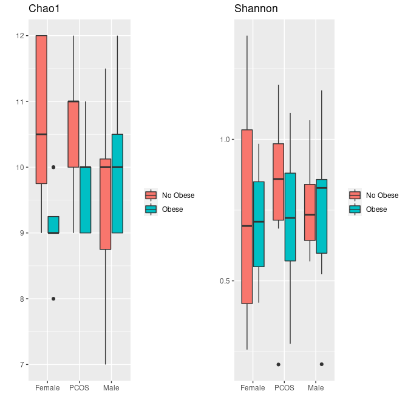

```r
> genus.abs.curated <- prune_species(speciesSums(phyloseq_genera_abs) > 0, phyloseq_genera_abs)
> alpha <- estimate_richness(phylum.abs.curated, measures = c("Shannon", "Chao1"))
> alpha$GROUP <- variables_in_bacteria$GROUP
> alpha$OBESE <- variables_in_bacteria$OBESE
> p1 <- ggplot(alpha, aes(x = GROUP, y = Chao1, interaction(alpha$GROUP), fill = alpha$OBESE)) +
+     geom_boxplot() + ylab("") + xlab("") + ggtitle("Chao1") + theme(legend.title = element_blank())
> p2 <- ggplot(alpha, aes(x = GROUP, y = Shannon, interaction(alpha$GROUP), fill = alpha$OBESE)) +
+     geom_boxplot() + ylab("") + xlab("") + ggtitle("Shannon") + theme(legend.title = element_blank())
> grid.arrange(p1, p2, ncol = 2)
```

#### Beta diversity.

Because beta diversity explains the ratio between regional and local species diversity

```r
> X.genus <- genera.abs[, -c(ncol(genera.abs) - 2, ncol(genera.abs) - 1, ncol(genera.abs))]
> dim(X.genus)
```

```
[1]  46 282
```

```r
> X.genus <- X.genus[, grep("^ud-", invert = T, colnames(X.genus))]
> dim(X.genus)
```

```
[1]  46 213
```

##### Jaccard Index.

```r
> # dim(genera.abs) X.genus <-
> # genera.abs[,-c(ncol(genera.abs)-2,ncol(genera.abs)-1,ncol(genera.abs))]
> # dim(X.genus)
```

```r
> X.genus <- X.genus[, colSums(X.genus) > 0]
> dim(X.genus)
```

```
[1]  46 213
```

```r
> jaccard_genus_D <- vegdist(X.genus, method = "jaccard")
> is.euclid(jaccard_genus_D)
```

```
[1] TRUE
```

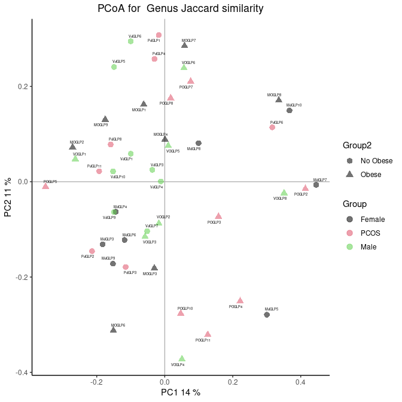

```r
> mds.genus <- cmdscale(jaccard_genus_D, eig = T)
> mds.genus.plot <- plotPcoA(mds.genus, grupos, "Genus Jaccard similarity", labels = rownames(X.genus))
> mds.genus.plot$grafico1
```

##### Soersen Index

```r
> soersen_genus_D <- vegdist((X.genus), method = "bray", binary = T)
> is.euclid(soersen_genus_D)
```

```
[1] FALSE
```

The distance is not euclidean, thus we proceed with non-metric MDS

```r
> nmds_ids_genus <- isoMDS(soersen_genus_D, trace = F)
> nmds_ids_genus$stress  # no se puede calcular
```

```
[1] 25.4297
```

```r
> nmds_meta_genus_soersen <- vegan::metaMDS(X.genus, engine = "monoMDS", trace = F,
+     binary = T, autotransform = T)
> nmds_meta_genus_soersen$stress * 100
```

```
[1] 25.02747
```

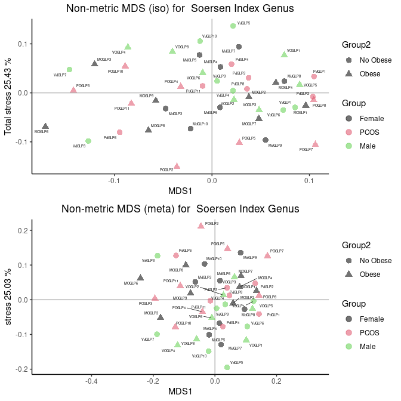

```r
> iso.genus.plot <- plotMDS(nmds_ids_genus, factor = grupos, title = "Soersen Index Genus",
+     method = "iso", labels = rownames(X.genus))
> meta.genus.plot <- plotMDS(nmds_meta_genus_soersen, factor = grupos, title = "Soersen Index Genus",
+     method = "meta", labels = rownames(X.genus))
> grid.arrange(iso.genus.plot$grafico1, meta.genus.plot$grafico1)
```

### Statisitcal Multivariate Descriptive analysis.

Due to the fact that we are dealing with with presence or absence of data, the best choice is to perform a Canonical Correspondence Analysis.

```r
> ca.genus <- ca(X.genus)
```

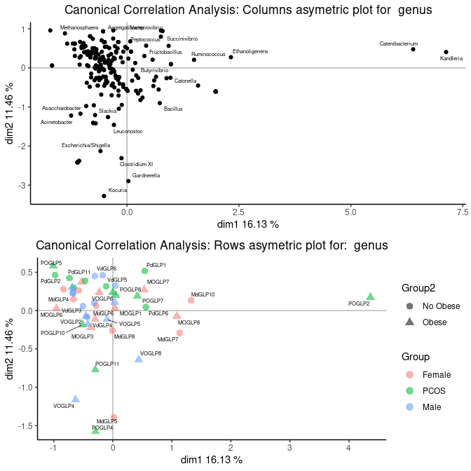

```r
> plot_genus <- plotCA_methods(ca.genus, grupos, "genus", labels.bac = colnames(X.genus),
+     labels.samples = rownames(X.genus), size = 2)
> grid.arrange(plot_genus$plot_cols, plot_genus$plot_rows)
```

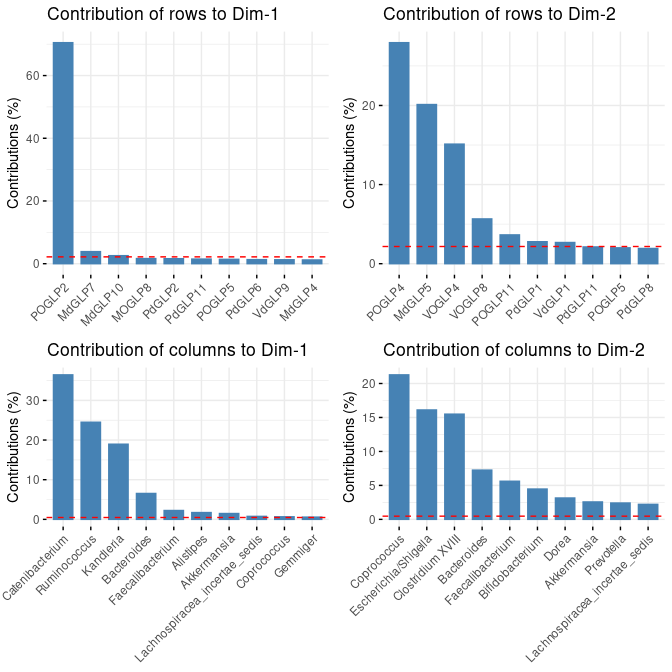

```r
> p1 <- fviz_contrib(ca.genus, choice = "row", axes = 1, top = 10)
> # Contributions of rows to dimension 2
> p2 <- fviz_contrib(ca.genus, choice = "row", axes = 2, top = 10)
>
> # Contributions of cols to dimension 1
> p3 <- fviz_contrib(ca.genus, choice = "col", axes = 1, top = 10)
> # Contributions of cols to dimension 2
> p4 <- fviz_contrib(ca.genus, choice = "col", axes = 2, top = 10)
> grid.arrange(p1, p2, p3, p4, ncol = 2)
```

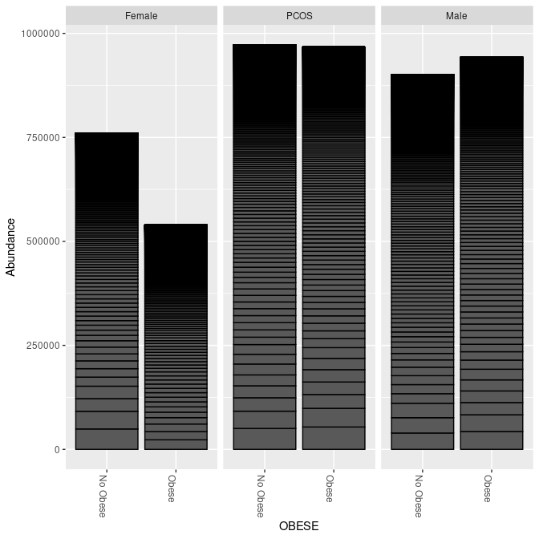

```r
> # p1<-plot_bar(phyloseq_genera_abs, x='genus', fill='GROUP',facet_grid =
> # ~OBESE)
> plot_bar(phyloseq_genera_abs, x = "OBESE", facet_grid = ~GROUP)
```